# Climate Water Loss Experiment - HOBO Data Logger Climate Summary

Savannah Weaver

2022

# Packages

```r
if (!require("tidyverse")) install.packages("tidyverse")
library("tidyverse")
if (!require("rmdformats")) install.packages("rmdformats")
library("rmdformats") # clean html R markdown format
```

# Background

This data was collected using Onset HOBO temperature and humidity dataloggers to assess the climates that lizards actually experienced during the course of our acclimation experiment.

# Load in Data

## File Names

The data is in a separate file for each download for each logger, so I need to compile each of those into one dataset. To do this, first I compile a list of the filenames I need to read-in.

```r
# make a list of file names of all data to load in
filenames <- list.files(path = "data/HOBOs")
```

## Function

Next, I make a function that will read in the data from each csv, name and organize the data correctly.

```r
# make a function to read in data from each csv file and add correct identifiers
read_HOBO_files <- function(filename) {

  # edit the filename inputted to funtion
  # to make a unique identifier for each logger
  name <- substr(filename, 1, nchar(filename)-15)
  # read in the csv file for this given filename
  dat <- read.csv(file.path("data/HOBOs", filename),
                # each csv has headers
                header = TRUE,
                # this is what I want to rename the col headers
                col.names = c("order", "date_time_PST", "temp_C",
                              "relative_humidity", "dew_pt_C",
                              # the 6,7,8th cols are not data
                              # logger use info we don't need
                              "mostly_blank", "mostly_blank", "mostly_blank")
                ) %>%
    # select only the cols with data we want
    # don't need order- just an arbitrary observation identifier
    # don't need "mostly_blank" cols- unnecessary logger use info
    # but get the rest of the cols with informative data
    dplyr::select(date_time_PST, temp_C, relative_humidity, dew_pt_C) %>%
    # add a column with the name of the HOBO the data is from
    dplyr::mutate(HOBO_ID = name)

  # return the dataframe for that single csv file
  dat
}
```

## Apply

Finally, I apply the function I made to all of the filenames I compiled, then put all of those dataframes into one dataframe for my analyses.

This will print warnings saying that header and col.names are different lengths, because the data has extra notes on logger usage that we read-in, but get rid of.

```r
# apply function to get data from all csvs
all_HOBO_data <- lapply(filenames, read_HOBO_files) %>%
  # paste all data files together into one df by row
  reduce(rbind) %>%
  mutate(date_time_PST = as.POSIXct(date_time_PST,
                                    format = "%m/%d/%Y %H:%M:%S")) %>%
  # remove missing data
  dplyr::filter(complete.cases(date_time_PST, relative_humidity)) %>%
  mutate(serial = (substr(HOBO_ID, 7, 15)), # select characters
         serial = str_trim(serial), # remove trailing white space
         serial = str_replace_all(serial, "[^A-z0-9]", "_"), # replace any special characters with underscores
         serial = as.factor(serial), # set class as factor
         temp_C = as.numeric(temp_C),
         relative_humidity = as.numeric(relative_humidity),
         dew_pt_C = as.numeric(dew_pt_C)
         )
```

[output not shown]

[output cut: 10 more lines]

[output not shown]

```r
summary(all_HOBO_data)
```

```
##  date_time_PST                        temp_C      relative_humidity
##  Min.   :2021-06-16 16:00:00.00   Min.   :16.72   Min.   :  6.47
##  1st Qu.:2021-07-02 08:30:00.00   1st Qu.:24.68   1st Qu.: 31.41
##  Median :2021-07-19 03:30:00.00   Median :25.27   Median : 46.68
##  Mean   :2021-07-22 04:26:33.51   Mean   :28.25   Mean   : 50.50
##  3rd Qu.:2021-08-12 10:00:00.00   3rd Qu.:34.70   3rd Qu.: 72.73
##  Max.   :2021-09-02 10:00:00.00   Max.   :38.34   Max.   :100.00
##     dew_pt_C        HOBO_ID               serial
##  Min.   :-14.98   Length:12893       20785309:2374
##  1st Qu.: 11.94   Class :character   20785311:2887
##  Median : 14.25   Mode  :character   20785317:2887
##  Mean   : 15.04                      20793609:2887
##  3rd Qu.: 21.34                      20932041:1258
##  Max.   : 35.06                      20932042: 600
```

```r
head(all_HOBO_data)
```

```
##            date_time_PST temp_C relative_humidity dew_pt_C
## 1102 2021-06-16 16:00:00  27.46             28.69     7.71
## 2101 2021-06-16 16:30:00  27.61             28.61     7.80
## 3100 2021-06-16 17:00:00  27.75             27.71     7.44
## 483  2021-06-16 17:30:00  27.94             27.08     7.27
## 512  2021-06-16 18:00:00  28.14             28.02     7.94
## 612  2021-06-16 18:30:00  29.30             37.74    13.42
##                                      HOBO_ID   serial
## 1102 serial 20785309 2021-06-26 16_18_44 PST 20785309
## 2101 serial 20785309 2021-06-26 16_18_44 PST 20785309
## 3100 serial 20785309 2021-06-26 16_18_44 PST 20785309
## 483  serial 20785309 2021-06-26 16_18_44 PST 20785309
## 512  serial 20785309 2021-06-26 16_18_44 PST 20785309
## 612  serial 20785309 2021-06-26 16_18_44 PST 20785309
```

# Data Wrangling

## Dates

The loggers were left on sometimes even though the experiment was not ongoing. I need to subset the data based on the date range for actual experiment days.

Trail 1: June 16-24 Trail 2: June 26 - July 4 Trial 3: July 20-28 Trial 4: August 8-16 Trial 5: August 22-30

Lizards were usually placed in the chambers late on the first day and taken out early on the last day, so I’ll only use from 8 pm on the first day up to 6 am the last day.

```r
t1_days <- seq(as.POSIXct("2021-06-16 20:00:00"),
               as.POSIXct("2021-06-24 06:00:00"), "1 min")
t2_days <- seq(as.POSIXct("2021-06-26 20:00:00"),
               as.POSIXct("2021-07-04 06:00:00"), "1 min")
t3_days <- seq(as.POSIXct("2021-07-20 20:00:00"),
               as.POSIXct("2021-07-28 06:00:00"), "1 min")
t4_days <- seq(as.POSIXct("2021-08-08 20:00:00"),
               as.POSIXct("2021-08-16 06:00:00"), "1 min")
t5_days <- seq(as.POSIXct("2021-08-22 20:00:00"),
               as.POSIXct("2021-08-30 06:00:00"), "1 min")
exp_dates <- c(t1_days, t2_days, t3_days, t4_days, t5_days)
```

Subset data:

```r
subset_HOBO_data <- all_HOBO_data %>%
  dplyr::filter(date_time_PST %in% exp_dates)
```

## Trial & Tmt

Add our notes about what bins/treatments the loggers were put in.

```r
# load HOBO assignment data
HOBO_tmts <- read.csv("./data/HOBO_assignments.csv") %>%
  dplyr::filter(trial != "5 rehab") %>%
  mutate(trial = as.factor(trial),
         serial = as.factor(serial),
         humidity_tmt = as.factor(humidity_tmt),
         temp_tmt = as.factor(temp_tmt),
         tmt = as.factor(paste(temp_tmt, humidity_tmt, sep = "-"))
         ) %>%
  dplyr::select(-notes, -in.google.drive.)
# combine
format_HOBO_data <- subset_HOBO_data %>%
  mutate(trial = as.factor(case_when(date_time_PST %in% t1_days ~ 1,
                                     date_time_PST %in% t2_days ~ 2,
                                     date_time_PST %in% t3_days ~ 3,
                                     date_time_PST %in% t4_days ~ 4,
                                     date_time_PST %in% t5_days ~ 5)),
         date_only = as.Date(date_time_PST)
         ) %>%
  left_join(HOBO_tmts, by = c("trial", "serial"))
summary(format_HOBO_data)
```

```
##  date_time_PST                        temp_C      relative_humidity
##  Min.   :2021-06-16 20:00:00.00   Min.   :16.72   Min.   :  6.47
##  1st Qu.:2021-06-29 05:15:00.00   1st Qu.:24.43   1st Qu.: 25.59
##  Median :2021-07-25 13:30:00.00   Median :26.30   Median : 43.10
##  Mean   :2021-07-24 05:02:27.30   Mean   :29.56   Mean   : 52.34
##  3rd Qu.:2021-08-13 21:30:00.00   3rd Qu.:35.22   3rd Qu.: 83.81
##  Max.   :2021-08-30 06:00:00.00   Max.   :38.34   Max.   :100.00
##
##     dew_pt_C        HOBO_ID               serial     trial
##  Min.   :-14.98   Length:8431        20785309:1428   1:1648
##  1st Qu.:  6.20   Class :character   20785311:1785   2:1428
##  Median : 17.98   Mode  :character   20785317:1785   3:1785
##  Mean   : 15.91                      20793609:1785   4:2142
##  3rd Qu.: 24.09                      20932041:1071   5:1428
##  Max.   : 35.06                      20932042: 577
##                                      20785308:   0
##    date_only          humidity_tmt temp_tmt            tmt
##  Min.   :2021-06-17   dry  :4284   cool:4284   cool-dry  :2142
##  1st Qu.:2021-06-29   humid:4147   hot :4147   cool-humid:2142
##  Median :2021-07-25                            hot-dry   :2142
##  Mean   :2021-07-23                            hot-humid :2005
##  3rd Qu.:2021-08-14
##  Max.   :2021-08-30
##
```

## Pretty Tmt Factor

reformat tmt factor:

```r
format_HOBO_data$tmt <- factor(format_HOBO_data$tmt,
                           levels = c("cool-humid",
                                      "hot-humid",
                                      "cool-dry",
                                      "hot-dry"),
                           labels = c("Cool Humid",
                                      "Hot Humid",
                                      "Cool Dry",
                                      "Hot Dry"))
summary(format_HOBO_data)
```

```
##  date_time_PST                        temp_C      relative_humidity
##  Min.   :2021-06-16 20:00:00.00   Min.   :16.72   Min.   :  6.47
##  1st Qu.:2021-06-29 05:15:00.00   1st Qu.:24.43   1st Qu.: 25.59
##  Median :2021-07-25 13:30:00.00   Median :26.30   Median : 43.10
##  Mean   :2021-07-24 05:02:27.30   Mean   :29.56   Mean   : 52.34
##  3rd Qu.:2021-08-13 21:30:00.00   3rd Qu.:35.22   3rd Qu.: 83.81
##  Max.   :2021-08-30 06:00:00.00   Max.   :38.34   Max.   :100.00
##
##     dew_pt_C        HOBO_ID               serial     trial
##  Min.   :-14.98   Length:8431        20785309:1428   1:1648
##  1st Qu.:  6.20   Class :character   20785311:1785   2:1428
##  Median : 17.98   Mode  :character   20785317:1785   3:1785
##  Mean   : 15.91                      20793609:1785   4:2142
##  3rd Qu.: 24.09                      20932041:1071   5:1428
##  Max.   : 35.06                      20932042: 577
##                                      20785308:   0
##    date_only          humidity_tmt temp_tmt            tmt
##  Min.   :2021-06-17   dry  :4284   cool:4284   Cool Humid:2142
##  1st Qu.:2021-06-29   humid:4147   hot :4147   Hot Humid :2005
##  Median :2021-07-25                            Cool Dry  :2142
##  Mean   :2021-07-23                            Hot Dry   :2142
##  3rd Qu.:2021-08-14
##  Max.   :2021-08-30
##
```

# Check Data

## Dates

```r
format_HOBO_data %>%
  group_by(trial) %>%
  summarise(min_date = (min(date_time_PST)),
            max_date = (max(date_time_PST)))
```

```
## # A tibble: 5 × 3
##   trial min_date            max_date
##   <fct> <dttm>              <dttm>
## 1 1     2021-06-16 20:00:00 2021-06-24 06:00:00
## 2 2     2021-06-26 20:00:00 2021-07-04 06:00:00
## 3 3     2021-07-20 20:00:00 2021-07-28 06:00:00
## 4 4     2021-08-08 20:00:00 2021-08-16 06:00:00
## 5 5     2021-08-22 20:00:00 2021-08-30 06:00:00
```

## Temperature

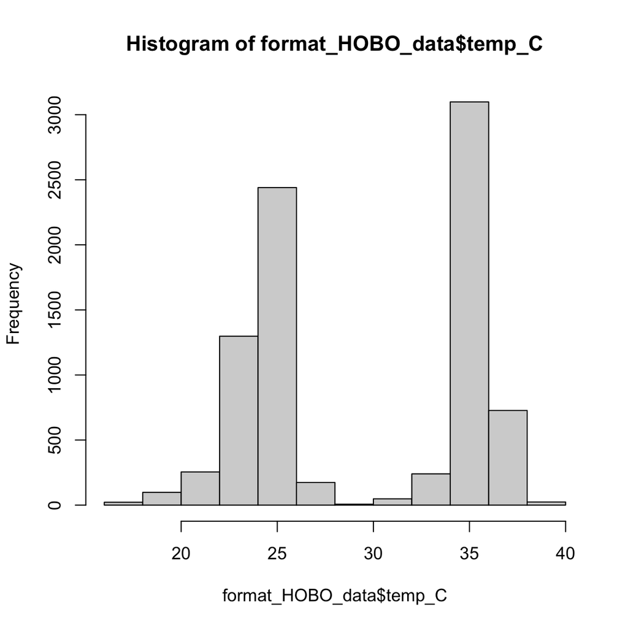

```r
hist(format_HOBO_data$temp_C)
```

```r
format_HOBO_data %>%
  group_by(trial, serial, tmt) %>%
  summarise(max(temp_C),
            mean(temp_C),
            min(temp_C)
            ) %>%
  arrange(tmt)
```

```
## # A tibble: 24 × 6
## # Groups:   trial, serial [24]
##    trial serial   tmt        `max(temp_C)` `mean(temp_C)` `min(temp_C)`
##    <fct> <fct>    <fct>              <dbl>          <dbl>         <dbl>
##  1 1     20793609 Cool Humid          26.6           24.0          17.8
##  2 2     20785311 Cool Humid          25.4           23.3          18.3
##  3 3     20785317 Cool Humid          26.2           24.0          20.8
##  4 4     20785309 Cool Humid          26.4           23.8          18.6
##  5 4     20932041 Cool Humid          25.8           23.4          16.7
##  6 5     20793609 Cool Humid          25.7           24.3          22.7
##  7 1     20785309 Hot Humid           36.1           34.6          29.2
##  8 1     20932042 Hot Humid           38.3           36.5          27.6
##  9 2     20785317 Hot Humid           35.8           34.7          28.7
## 10 3     20932041 Hot Humid           36.4           34.6          25.4
## # … with 14 more rows
```

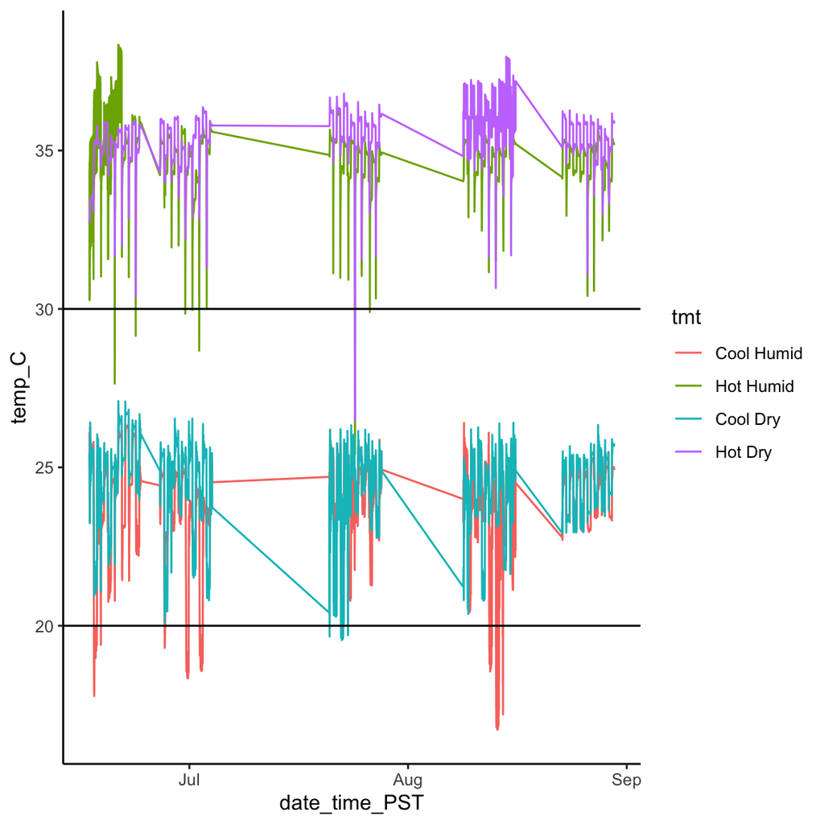

```r
format_HOBO_data %>%
  ggplot() +
  geom_line(aes(x = date_time_PST,
                y = temp_C,
                color = tmt)) +
  theme_classic() +
  geom_hline(yintercept = 30) +
  geom_hline(yintercept = 20)
```

There’s a chance the values <30 for the hot tmt and <20 for the cool tmt are erroneous values.

```r
format_HOBO_data %>%
  dplyr::filter(temp_tmt == "hot" & temp_C < 30) %>%
  arrange(temp_C)
```

```
##          date_time_PST temp_C relative_humidity dew_pt_C
## 1  2021-07-24 11:30:00  25.40             89.78    23.63
## 2  2021-07-24 11:30:00  26.48             34.44     9.55
## 3  2021-06-20 10:00:00  27.64             60.87    19.42
## 4  2021-07-02 09:30:00  28.68             83.00    25.53
## 5  2021-06-23 09:30:00  29.15             92.44    27.83
## 6  2021-07-24 12:00:00  29.32             39.31    14.07
## 7  2021-06-20 10:30:00  29.48             98.96    29.34
## 8  2021-06-30 10:00:00  29.85             97.15    29.38
## 9  2021-07-26 14:00:00  29.90             82.90    26.71
## 10 2021-07-01 10:30:00  29.97             94.45    29.02
##                                    HOBO_ID   serial trial  date_only
## 1  serial 20932041 2021-07-28 11_25_35 PST 20932041     3 2021-07-24
## 2  serial 20785309 2021-07-28 11_19_50 PST 20785309     3 2021-07-24
## 3  serial 20932042 2021-06-21 09_54_42 PST 20932042     1 2021-06-20
```

[output cut: 18 more lines]

```r
format_HOBO_data %>%
  dplyr::filter(temp_tmt == "cool" & temp_C < 20) %>%
  arrange(temp_C)
```

```
##           date_time_PST temp_C relative_humidity dew_pt_C
## 1   2021-08-13 15:30:00  16.72             94.40    15.83
## 2   2021-08-13 16:00:00  16.72             94.75    15.89
## 3   2021-08-13 18:00:00  16.76             94.99    15.97
## 4   2021-08-13 13:00:00  16.78             93.68    15.78
## 5   2021-08-13 17:30:00  16.78             94.73    15.95
## 6   2021-08-13 15:00:00  16.84             94.31    15.94
## 7   2021-08-13 20:00:00  16.86             95.08    16.08
## 8   2021-08-13 19:30:00  16.87             94.89    16.06
## 9   2021-08-13 12:30:00  16.91             91.46    15.53
## 10  2021-08-13 17:00:00  16.91             94.87    16.10
## 11  2021-08-13 16:30:00  16.93             94.93    16.14
## 12  2021-08-13 18:30:00  16.96             95.11    16.20
## 13  2021-08-13 19:00:00  17.03             94.96    16.24
## 14  2021-08-13 14:30:00  17.04             94.28    16.13
```

[output cut: 345 more lines]

There are only 10 points <30C for the hot treatment, which is very few compared to the total number of measurements. I think these observations are from when the lizards (thus loggers) were out of the incubators for daily checkups. But, this is still technically characteristic of the environment the lizards experienced, and it’s very few points that are unlikely to affect the summary statistics, so I’ll leave them.

There are many more points <20C for the cool treatment. The lowest is still ~17C, and most of them are very close to 20. The bottom of the cool incubator tended to get extra cold, so I’m not worried about the validity of these points.

All the temperature observations are valid.

## Humidity

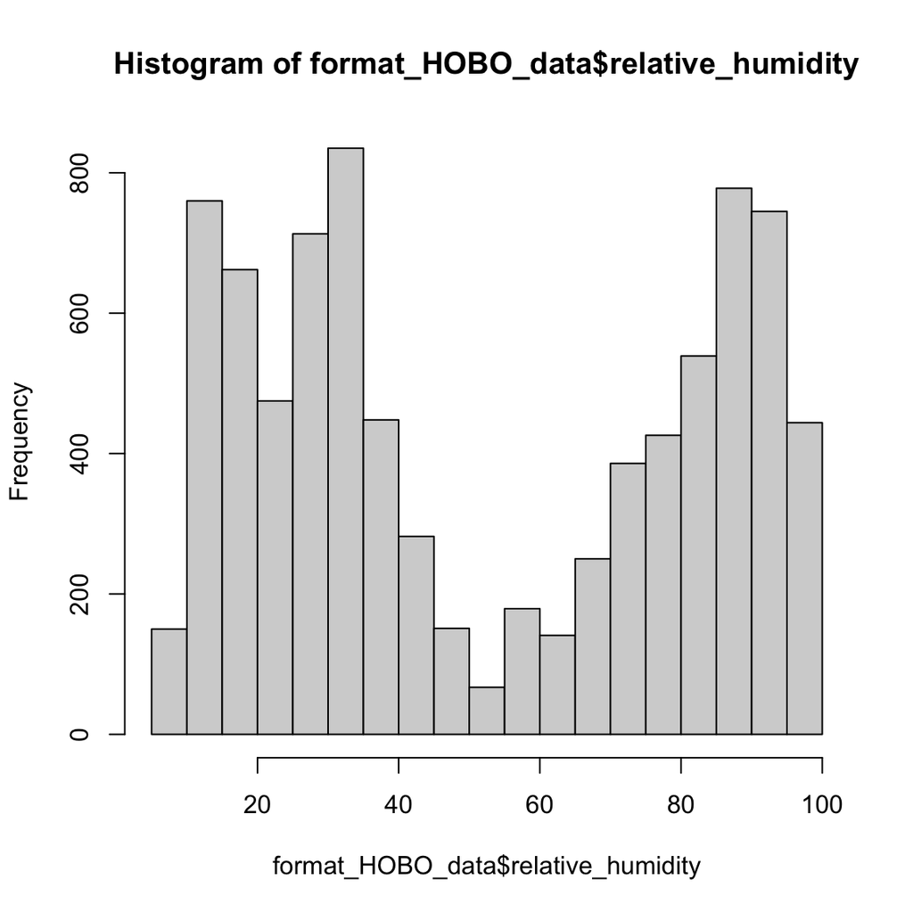

```r
hist(format_HOBO_data$relative_humidity)
```

```r
format_HOBO_data %>%
  group_by(trial, serial, tmt) %>%
  summarise(max(relative_humidity),
            mean(relative_humidity),
            min(relative_humidity)
            ) %>%
  arrange(tmt)
```

```
## # A tibble: 24 × 6
## # Groups:   trial, serial [24]
##    trial serial   tmt        `max(relative_humidity)` mean(relative_hu…¹ min(r…²
##    <fct> <fct>    <fct>                         <dbl>              <dbl>   <dbl>
##  1 1     20793609 Cool Humid                     99.7               46.4    6.75
##  2 2     20785311 Cool Humid                    100                 93.2   68.3
##  3 3     20785317 Cool Humid                     92.8               76.3   60.4
##  4 4     20785309 Cool Humid                    100                 90.3   66.0
##  5 4     20932041 Cool Humid                     96.5               75.4   52.2
##  6 5     20793609 Cool Humid                     97.6               88.1   64.4
##  7 1     20785309 Hot Humid                      99.0               81.4   36.3
##  8 1     20932042 Hot Humid                      83.7               73.3   49.4
##  9 2     20785317 Hot Humid                      97.2               85.6   63.9
## 10 3     20932041 Hot Humid                      89.8               69.4   23.8
## # … with 14 more rows, and abbreviated variable names
## #   ¹`mean(relative_humidity)`, ²`min(relative_humidity)`
```

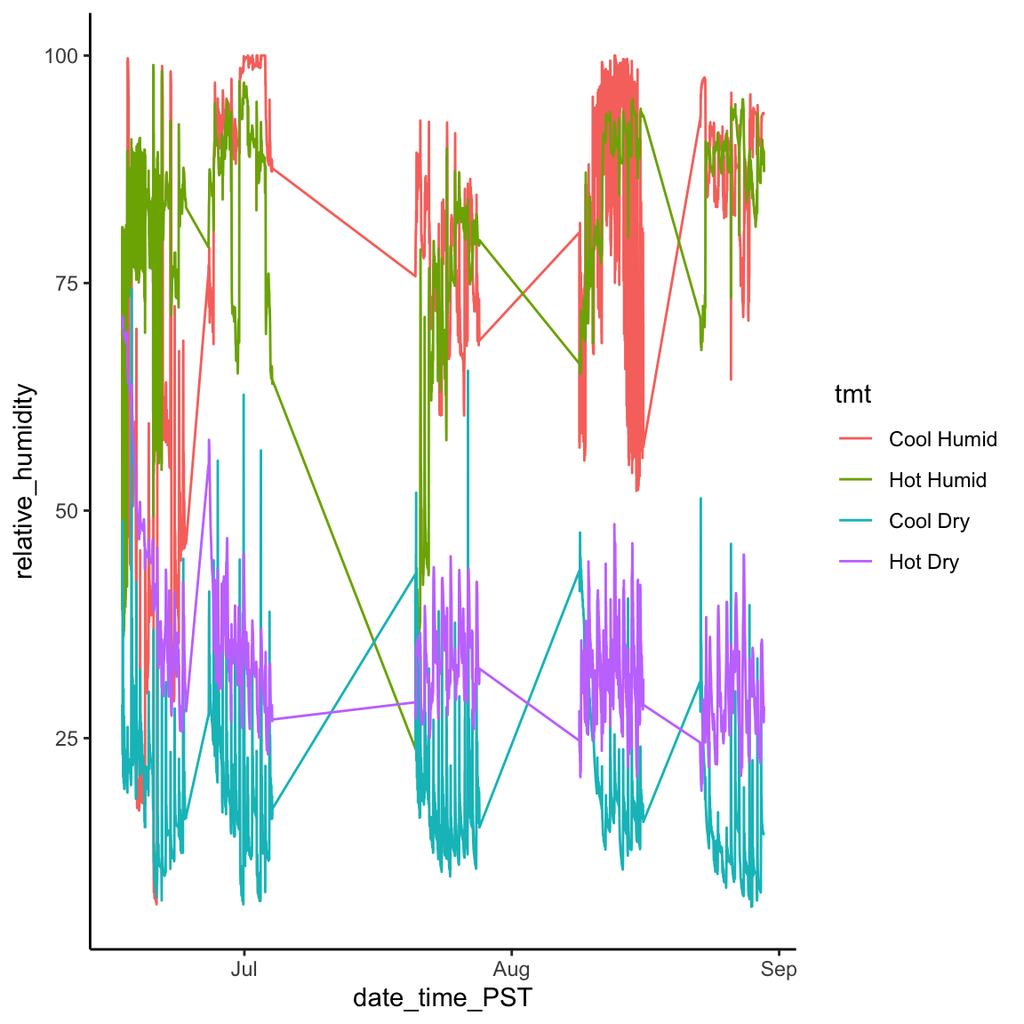

```r
format_HOBO_data %>%
  ggplot() +
  geom_line(aes(x = date_time_PST,
                y = relative_humidity,
                color = tmt)) +
  theme_classic()
```

# Statistics

## Treatment Differences

Calculate vapor pressure deficit based on temp/RH values using the formula in the book “Environmental Biophysics” by Campbell & Norman, 1998. Then, get mean + SD stats for each variable.

```r
format_HOBO_data_w_VPD <- format_HOBO_data %>%
  # vapor pressure calculations based on Campbell & Normal 1998
  mutate(e_s_kPa = 0.611 * exp((17.502*temp_C)/(temp_C + 240.97)),
         e_a_kPa = e_s_kPa*(relative_humidity/100),
         VPD_kPa = e_s_kPa - e_a_kPa
         )

tmt_only_means <- format_HOBO_data_w_VPD %>%
  group_by(tmt) %>%
  summarise(temp_mean = mean(temp_C),
            temp_SD = sd(temp_C),
            temp_min = min(temp_C),
            temp_max = max(temp_C),

            humidity_mean = mean(relative_humidity),
            humidity_SD = sd(relative_humidity),
            humidity_min = min(relative_humidity),
            humidity_max = max(relative_humidity),

            e_a_mean = mean(e_a_kPa),
            e_a_SD = sd(e_a_kPa),
            e_a_min = min(e_a_kPa),
            e_a_max = max(e_a_kPa),

            VPD_mean = mean(VPD_kPa),
            VPD_SD = sd(VPD_kPa),
            VPD_min = min(VPD_kPa),
            VPD_max = max(VPD_kPa),

            )

tmt_only_means
```

```
## # A tibble: 4 × 17
##   tmt    temp_…¹ temp_SD temp_…² temp_…³ humid…⁴ humid…⁵ humid…⁶ humid…⁷ e_a_m…⁸
##   <fct>    <dbl>   <dbl>   <dbl>   <dbl>   <dbl>   <dbl>   <dbl>   <dbl>   <dbl>
## 1 Cool …    23.8   1.61     16.7    26.6    78.3   19.6     6.75   100     2.31
## 2 Hot H…    34.9   1.14     25.4    38.3    80.9   12.5    23.8     99.0   4.52
## 3 Cool …    24.4   1.35     19.6    27.1    17.9    7.44    6.47    74.4   0.548
## 4 Hot D…    35.5   0.900    26.5    38.0    34.1    8.40   19.2     71.4   1.97
## # … with 7 more variables: e_a_SD <dbl>, e_a_min <dbl>, e_a_max <dbl>,
## #   VPD_mean <dbl>, VPD_SD <dbl>, VPD_min <dbl>, VPD_max <dbl>, and abbreviated
## #   variable names ¹temp_mean, ²temp_min, ³temp_max, ⁴humidity_mean,
## #   ⁵humidity_SD, ⁶humidity_min, ⁷humidity_max, ⁸e_a_mean
```

### Make Pretty Version

```r
tmt_only_means_pretty <- tmt_only_means %>%
  mutate(trial = "Average",
         temperature_C = paste(round(temp_mean, 1), "±",
                                          round(temp_SD, 1), sep = " "),
         relative_humidity_percent = paste(round(humidity_mean, 0), "±",
                                          round(humidity_SD, 0), sep = " "),
         water_vapor_pressure_kPa = paste(round(e_a_mean, 1), "±",
                                          round(e_a_SD, 1), sep = " "),
         vapor_pressure_deficit_kPa = paste(round(VPD_mean, 1), "±",
                                          round(VPD_SD, 1), sep = " ")) %>%
  dplyr::select(tmt, trial,
                temperature_C, relative_humidity_percent,
                water_vapor_pressure_kPa, vapor_pressure_deficit_kPa) %>%
  arrange(tmt)

tmt_only_means_pretty
```

```
## # A tibble: 4 × 6
##   tmt        trial   temperature_C relative_humidity_percent water_vap…¹ vapor…²
##   <fct>      <chr>   <chr>         <chr>                     <chr>       <chr>
## 1 Cool Humid Average 23.8 ± 1.6    78 ± 20                   2.3 ± 0.6   0.6 ± …
## 2 Hot Humid  Average 34.9 ± 1.1    81 ± 13                   4.5 ± 0.7   1.1 ± …
## 3 Cool Dry   Average 24.4 ± 1.3    18 ± 7                    0.5 ± 0.2   2.5 ± …
## 4 Hot Dry    Average 35.5 ± 0.9    34 ± 8                    2 ± 0.5     3.8 ± …
## # … with abbreviated variable names ¹water_vapor_pressure_kPa,
## #   ²vapor_pressure_deficit_kPa
```

```r
write.csv(tmt_only_means_pretty, "./results_statistics/HOBO_mean_diffs_tmt_only.csv")
```

## Trial Differences

Were there also differences across the trials (experiment iterations)?

```r
tmt_trial_means <- format_HOBO_data_w_VPD %>%
  group_by(tmt, trial) %>%
  summarise(temp_mean_tmttrial = mean(temp_C),
            temp_SD_tmttrial = sd(temp_C),
            humidity_mean_tmttrial = mean(relative_humidity),
            humidity_SD_tmttrial = sd(relative_humidity),
            e_a_mean_tmttrial = mean(e_a_kPa),
            e_a_SD_tmttrial = sd(e_a_kPa),
            VPD_mean_tmttrial = mean(VPD_kPa),
            VPD_SD_tmttrial = sd(VPD_kPa)
            ) %>%
  arrange(trial)
```

[output not shown]

```r
tmt_trial_means
```

```
## # A tibble: 20 × 10
## # Groups:   tmt [4]
##    tmt     trial temp_…¹ temp_…² humid…³ humid…⁴ e_a_m…⁵ e_a_S…⁶ VPD_m…⁷ VPD_S…⁸
##    <fct>   <fct>   <dbl>   <dbl>   <dbl>   <dbl>   <dbl>   <dbl>   <dbl>   <dbl>
##  1 Cool H… 1        24.0   1.84     46.4   19.8    1.39    0.597   1.61    0.608
##  2 Hot Hu… 1        35.3   1.52     78.3   12.3    4.50    0.717   1.25    0.687
##  3 Cool D… 1        24.9   1.40     19.1    7.38   0.596   0.227   2.56    0.348
##  4 Hot Dry 1        35.0   0.783    44.1   12.4    2.48    0.651   3.17    0.737
##  5 Cool H… 2        23.3   1.78     93.2    7.25   2.67    0.276   0.205   0.225
##  6 Hot Hu… 2        34.7   0.947    85.6    9.07   4.73    0.489   0.802   0.525
##  7 Cool D… 2        24.3   1.52     18.9    8.20   0.579   0.265   2.46    0.306
##  8 Hot Dry 2        35.3   0.731    34.6    6.27   1.98    0.372   3.73    0.388
##  9 Cool H… 3        24.0   1.16     76.3    7.22   2.29    0.317   0.702   0.198
## 10 Hot Hu… 3        34.6   1.05     69.4   14.9    3.81    0.769   1.71    0.886
## 11 Cool D… 3        24.3   1.38     17.6    6.25   0.533   0.189   2.51    0.278
## 12 Hot Dry 3        35.6   0.896    33.5    4.37   1.95    0.297   3.86    0.256
## 13 Cool H… 4        23.6   1.78     82.8   14.0    2.42    0.472   0.504   0.415
## 14 Hot Hu… 4        34.9   0.751    85.5    8.34   4.77    0.502   0.811   0.474
## 15 Cool D… 4        24.1   1.31     20.6    8.18   0.620   0.249   2.38    0.290
## 16 Hot Dry 4        36.0   0.943    31.6    4.97   1.88    0.313   4.07    0.359
## 17 Cool H… 5        24.3   0.752    88.1    5.79   2.67    0.244   0.357   0.169
## 18 Hot Hu… 5        34.6   0.696    87.3    5.97   4.81    0.356   0.700   0.337
## 19 Cool D… 5        24.5   0.862    13.7    6.23   0.426   0.200   2.66    0.211
## 20 Hot Dry 5        35.4   0.597    29.2    5.10   1.68    0.309   4.06    0.299
## # … with abbreviated variable names ¹temp_mean_tmttrial, ²temp_SD_tmttrial,
## #   ³humidity_mean_tmttrial, ⁴humidity_SD_tmttrial, ⁵e_a_mean_tmttrial,
## #   ⁶e_a_SD_tmttrial, ⁷VPD_mean_tmttrial, ⁸VPD_SD_tmttrial
```

### Export for other Rmds

First, add overall tmt means:

```r
tmt_only_means_sub <- tmt_only_means %>%
  dplyr::select(tmt,
                temp_C = temp_mean,
                humidity_percent = humidity_mean,
                e_a_kPa = e_a_mean,
                VPD_kPa = VPD_mean) %>%
  mutate(temp_C = round(temp_C, 1),
         humidity_percent = round(humidity_percent, 1),
         e_a_kPa = round(e_a_kPa, 1),
         VPD_kPa = round(VPD_kPa, 1))
tmt_only_means_sub
```

```
## # A tibble: 4 × 5
##   tmt        temp_C humidity_percent e_a_kPa VPD_kPa
##   <fct>       <dbl>            <dbl>   <dbl>   <dbl>
## 1 Cool Humid   23.8             78.3     2.3     0.6
## 2 Hot Humid    34.9             80.9     4.5     1.1
## 3 Cool Dry     24.4             17.9     0.5     2.5
## 4 Hot Dry      35.5             34.1     2       3.8
```

```r
tmt_trial_means_plus <- tmt_trial_means %>%
  left_join(tmt_only_means_sub, by = 'tmt')
```

```r
write_rds(tmt_trial_means_plus, "./data/HOBO_tmt_trial_diffs.RDS")
```

### Export Pretty Version

```r
tmt_trial_means_pretty <- tmt_trial_means %>%
  mutate(temperature_C = paste(round(temp_mean_tmttrial, 1), "±",
                                          round(temp_SD_tmttrial, 1), sep = " "),
         relative_humidity_percent = paste(round(humidity_mean_tmttrial, 0), "±",
                                          round(humidity_SD_tmttrial, 0), sep = " "),
         water_vapor_pressure_kPa = paste(round(e_a_mean_tmttrial, 1), "±",
                                          round(e_a_SD_tmttrial, 1), sep = " "),
         vapor_pressure_deficit_kPa = paste(round(VPD_mean_tmttrial, 1), "±",
                                          round(VPD_SD_tmttrial, 1), sep = " ")) %>%
  dplyr::select(tmt, trial,
                temperature_C, relative_humidity_percent,
                water_vapor_pressure_kPa, vapor_pressure_deficit_kPa) %>%
  rbind(tmt_only_means_pretty) %>%
  arrange(tmt, trial)

tmt_trial_means_pretty
```

```
## # A tibble: 24 × 6
## # Groups:   tmt [4]
##    tmt        trial   temperature_C relative_humidity_percent water_va…¹ vapor…²
##    <fct>      <chr>   <chr>         <chr>                     <chr>      <chr>
##  1 Cool Humid 1       24 ± 1.8      46 ± 20                   1.4 ± 0.6  1.6 ± …
##  2 Cool Humid 2       23.3 ± 1.8    93 ± 7                    2.7 ± 0.3  0.2 ± …
##  3 Cool Humid 3       24 ± 1.2      76 ± 7                    2.3 ± 0.3  0.7 ± …
##  4 Cool Humid 4       23.6 ± 1.8    83 ± 14                   2.4 ± 0.5  0.5 ± …
##  5 Cool Humid 5       24.3 ± 0.8    88 ± 6                    2.7 ± 0.2  0.4 ± …
##  6 Cool Humid Average 23.8 ± 1.6    78 ± 20                   2.3 ± 0.6  0.6 ± …
##  7 Hot Humid  1       35.3 ± 1.5    78 ± 12                   4.5 ± 0.7  1.3 ± …
##  8 Hot Humid  2       34.7 ± 0.9    86 ± 9                    4.7 ± 0.5  0.8 ± …
##  9 Hot Humid  3       34.6 ± 1      69 ± 15                   3.8 ± 0.8  1.7 ± …
## 10 Hot Humid  4       34.9 ± 0.8    85 ± 8                    4.8 ± 0.5  0.8 ± …
## # … with 14 more rows, and abbreviated variable names
## #   ¹water_vapor_pressure_kPa, ²vapor_pressure_deficit_kPa
```

```r
write.csv(tmt_trial_means_pretty, "./results_statistics/HOBO_mean_diffs.csv")
```

## Models

Run linear models with pairwise post-hoc tests to determine when and how much climate varied among treatments.

```r
# temperature
temp_mod <- lm(data = format_HOBO_data,
               temp_C ~ tmt * trial)
a_temp_mod <- aov(temp_mod)
ph_temp_mod <- TukeyHSD(a_temp_mod)
summary(temp_mod)
```

```
##
## Call:
## lm(formula = temp_C ~ tmt * trial, data = format_HOBO_data)
##
## Residuals:
##     Min      1Q  Median      3Q     Max
## -9.2267 -0.5199  0.1815  0.7600  2.9955
##
## Coefficients:
##                      Estimate Std. Error t value Pr(>|t|)
## (Intercept)         24.037563   0.065595 366.452  < 2e-16 ***
## tmtHot Humid        11.306960   0.083456 135.484  < 2e-16 ***
## tmtCool Dry          0.837731   0.092766   9.031  < 2e-16 ***
## tmtHot Dry          11.010448   0.092766 118.691  < 2e-16 ***
## trial2              -0.734426   0.092766  -7.917 2.74e-15 ***
## trial3              -0.007423   0.092766  -0.080  0.93622
## trial4              -0.447801   0.080338  -5.574 2.57e-08 ***
## trial5               0.223613   0.092766   2.411  0.01595 *
## tmtHot Humid:trial2  0.061163   0.124782   0.490  0.62403
## tmtCool Dry:trial2   0.131625   0.131191   1.003  0.31574
## tmtHot Dry:trial2    0.945882   0.131191   7.210 6.08e-13 ***
## tmtHot Humid:trial3 -0.710378   0.124782  -5.693 1.29e-08 ***
## tmtCool Dry:trial3  -0.599370   0.122718  -4.884 1.06e-06 ***
## tmtHot Dry:trial3    0.532829   0.131191   4.061 4.92e-05 ***
## tmtHot Humid:trial4 -0.044790   0.115841  -0.387  0.69903
## tmtCool Dry:trial4  -0.373711   0.122718  -3.045  0.00233 **
## tmtHot Dry:trial4    1.402941   0.113614  12.348  < 2e-16 ***
## tmtHot Humid:trial5 -0.961526   0.124782  -7.706 1.45e-14 ***
## tmtCool Dry:trial5  -0.568880   0.131191  -4.336 1.47e-05 ***
## tmtHot Dry:trial5    0.089244   0.131191   0.680  0.49636
## ---
## Signif. codes:  0 '***' 0.001 '**' 0.01 '*' 0.05 '.' 0.1 ' ' 1
##
## Residual standard error: 1.239 on 8411 degrees of freedom
## Multiple R-squared:  0.9531, Adjusted R-squared:  0.953
## F-statistic:  9002 on 19 and 8411 DF,  p-value: < 2.2e-16
```

```r
temp_mod_df <- data.frame(broom::tidy(ph_temp_mod)) %>%
  arrange(desc(adj.p.value))
write.csv(temp_mod_df, "./results_statistics/HOBO_temp_pairwise_diffs.csv")

# humidity
humidity_mod <- lm(data = format_HOBO_data,
                   relative_humidity ~ tmt * trial)
a_humid_mod <- aov(humidity_mod)
ph_humid_mod <- TukeyHSD(a_humid_mod)
summary(humidity_mod)
```

```
##
## Call:
## lm(formula = relative_humidity ~ tmt * trial, data = format_HOBO_data)
##
## Residuals:
##     Min      1Q  Median      3Q     Max
## -45.531  -4.378   0.038   5.433  55.347
##
## Coefficients:
##                     Estimate Std. Error t value Pr(>|t|)
## (Intercept)          46.3801     0.5073  91.425  < 2e-16 ***
## tmtHot Humid         31.9115     0.6454  49.442  < 2e-16 ***
## tmtCool Dry         -27.3272     0.7174 -38.090  < 2e-16 ***
## tmtHot Dry           -2.2771     0.7174  -3.174  0.00151 **
## trial2               46.7719     0.7174  65.193  < 2e-16 ***
## trial3               29.9361     0.7174  41.727  < 2e-16 ***
## trial4               36.4580     0.6213  58.679  < 2e-16 ***
## trial5               41.7519     0.7174  58.196  < 2e-16 ***
## tmtHot Humid:trial2 -39.4138     0.9650 -40.842  < 2e-16 ***
## tmtCool Dry:trial2  -46.9146     1.0146 -46.239  < 2e-16 ***
## tmtHot Dry:trial2   -56.2866     1.0146 -55.476  < 2e-16 ***
## tmtHot Humid:trial3 -38.8562     0.9650 -40.264  < 2e-16 ***
## tmtCool Dry:trial3  -31.4109     0.9491 -33.096  < 2e-16 ***
## tmtHot Dry:trial3   -40.5434     1.0146 -39.960  < 2e-16 ***
## tmtHot Humid:trial4 -29.2694     0.8959 -32.671  < 2e-16 ***
## tmtCool Dry:trial4  -34.8869     0.9491 -36.759  < 2e-16 ***
## tmtHot Dry:trial4   -48.9315     0.8787 -55.688  < 2e-16 ***
## tmtHot Humid:trial5 -32.7335     0.9650 -33.919  < 2e-16 ***
## tmtCool Dry:trial5  -47.0594     1.0146 -46.382  < 2e-16 ***
## tmtHot Dry:trial5   -56.6494     1.0146 -55.834  < 2e-16 ***
## ---
## Signif. codes:  0 '***' 0.001 '**' 0.01 '*' 0.05 '.' 0.1 ' ' 1
##
## Residual standard error: 9.585 on 8411 degrees of freedom
## Multiple R-squared:  0.9001, Adjusted R-squared:  0.8998
## F-statistic:  3987 on 19 and 8411 DF,  p-value: < 2.2e-16
```

```r
humid_mod_df <- data.frame(broom::tidy(ph_humid_mod)) %>%
  arrange(desc(adj.p.value))
write.csv(humid_mod_df,
          "./results_statistics/HOBO_humidity_pairwise_diffs.csv")

# VPD
VPD_mod <- lm(data = format_HOBO_data_w_VPD,
                   VPD_kPa ~ tmt * trial)
a_VPD_mod <- aov(VPD_mod)
ph_VPD_mod <- TukeyHSD(a_VPD_mod)
summary(VPD_mod)
```

```
##
## Call:
## lm(formula = VPD_kPa ~ tmt * trial, data = format_HOBO_data_w_VPD)
##
## Residuals:
##      Min       1Q   Median       3Q      Max
## -1.73732 -0.25254 -0.01186  0.20667  2.53945
##
## Coefficients:
##                     Estimate Std. Error t value Pr(>|t|)
## (Intercept)          1.61469    0.02336   69.14   <2e-16 ***
## tmtHot Humid        -0.36384    0.02972  -12.24   <2e-16 ***
## tmtCool Dry          0.94151    0.03303   28.50   <2e-16 ***
## tmtHot Dry           1.55040    0.03303   46.94   <2e-16 ***
## trial2              -1.40938    0.03303  -42.67   <2e-16 ***
## trial3              -0.91271    0.03303  -27.63   <2e-16 ***
## trial4              -1.11108    0.02860  -38.84   <2e-16 ***
## trial5              -1.25776    0.03303  -38.08   <2e-16 ***
## tmtHot Humid:trial2  0.96037    0.04443   21.62   <2e-16 ***
## tmtCool Dry:trial2   1.31645    0.04671   28.18   <2e-16 ***
## tmtHot Dry:trial2    1.97857    0.04671   42.36   <2e-16 ***
## tmtHot Humid:trial3  1.37254    0.04443   30.89   <2e-16 ***
## tmtCool Dry:trial3   0.86238    0.04369   19.74   <2e-16 ***
## tmtHot Dry:trial3    1.60837    0.04671   34.43   <2e-16 ***
## tmtHot Humid:trial4  0.67151    0.04125   16.28   <2e-16 ***
## tmtCool Dry:trial4   0.93429    0.04369   21.38   <2e-16 ***
## tmtHot Dry:trial4    2.01450    0.04045   49.80   <2e-16 ***
## tmtHot Humid:trial5  0.70723    0.04443   15.92   <2e-16 ***
## tmtCool Dry:trial5   1.35765    0.04671   29.07   <2e-16 ***
## tmtHot Dry:trial5    2.15454    0.04671   46.12   <2e-16 ***
## ---
## Signif. codes:  0 '***' 0.001 '**' 0.01 '*' 0.05 '.' 0.1 ' ' 1
##
## Residual standard error: 0.4413 on 8411 degrees of freedom
## Multiple R-squared:  0.8971, Adjusted R-squared:  0.8968
## F-statistic:  3858 on 19 and 8411 DF,  p-value: < 2.2e-16
```

```r
VPD_mod_df <- data.frame(broom::tidy(ph_VPD_mod)) %>%
  arrange(desc(contrast))
write.csv(VPD_mod_df,
          "./results_statistics/HOBO_VPD_pairwise_diffs.csv")
```

## Boxplots

Simple plots looking at the distribution of temperature and humidity for each treatment group:

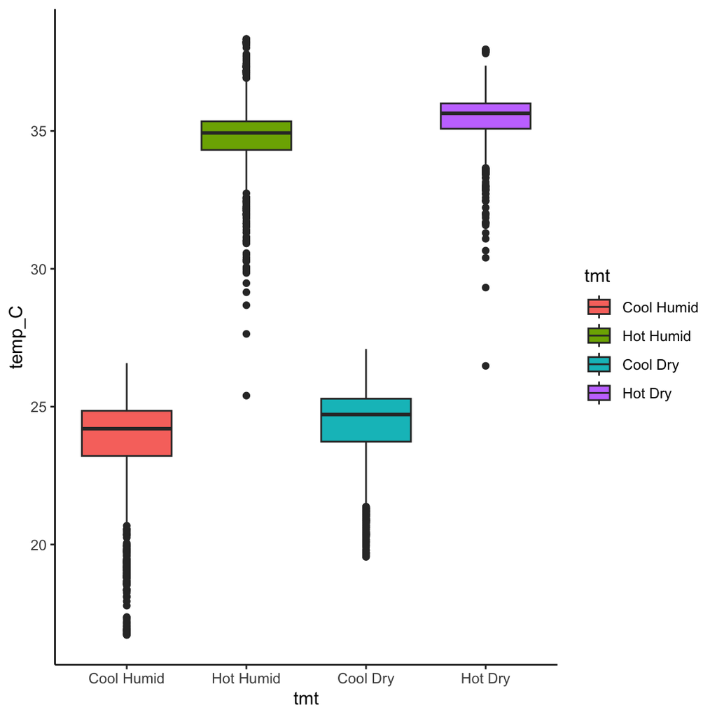

```r
format_HOBO_data %>%
  ggplot() +
  geom_boxplot(aes(x = tmt,
                   y = temp_C,
                   fill = tmt)) +
  theme_classic()
```

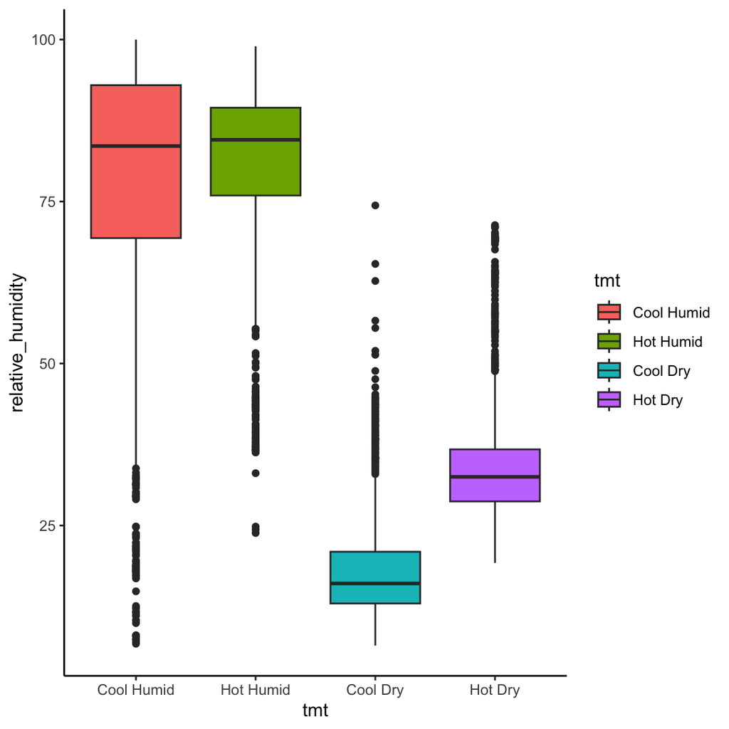

```r
format_HOBO_data %>%
  ggplot() +
  geom_boxplot(aes(x = tmt,
                   y = relative_humidity,
                   fill = tmt)) +
  theme_classic()
```

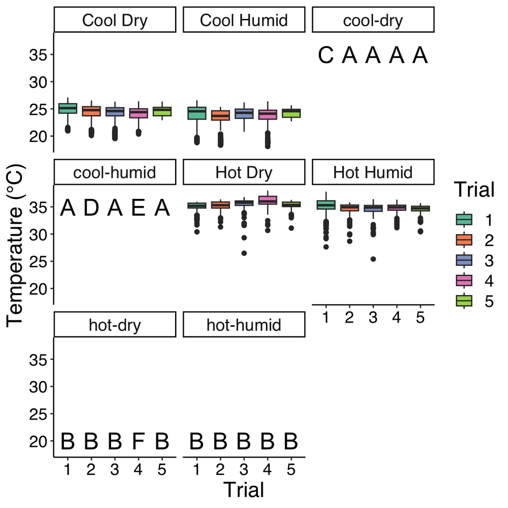

```r
# create ANOVA labels
anova_labels_temp <- data.frame(tmt = c("cool-dry",
                                   "cool-humid",
                                   "hot-dry",
                                   "hot-humid"
                                  ),
                                # c-d, c-h, h-d, h-h
                           t1 = c("C", "A", "B", "B"),
                           t2 = c("A", "D", "B", "B"),
                           t3 = c("A", "A", "B", "B"),
                           t4 = c("A", "E", "F", "B"),
                           t5 = c("A", "A", "B", "B"))
# plot!
format_HOBO_data %>%
  ggplot() +
  geom_boxplot(aes(x = trial,
                   y = temp_C,
                   fill = trial)) +
  theme_classic() +
  facet_wrap(~tmt) +
  xlab("Trial") +
  ylab("Temperature (°C)") +
  ylim(18,38) +
  scale_fill_brewer(palette = "Set2",
                    name = "Trial") +
  theme(text = element_text(color = "black",
                            family = "sans",
                            size = 18),
        axis.text = element_text(color = "black",
                                 family = "sans",
                                 size = 14),
        legend.text.align = 0,
        legend.position = "right") +
  # trial 1 labels
  geom_text(data = anova_labels_temp,
            size = 7,
            mapping = aes(x = 1, y = c(35,35,20,20), label = t1)) +
  # trial 2 labels
  geom_text(data = anova_labels_temp,
            size = 7,
            mapping = aes(x = 2, y = c(35,35,20,20), label = t2)) +
  # trial 3 labels
  geom_text(data = anova_labels_temp,
            size = 7,
            mapping = aes(x = 3, y = c(35,35,20,20), label = t3)) +
  # trial 4 labels
  geom_text(data = anova_labels_temp,
            size = 7,
            mapping = aes(x = 4, y = c(35,35,20,20), label = t4)) +
  # trial 5 labels
  geom_text(data = anova_labels_temp,
            size = 7,
            mapping = aes(x = 5, y = c(35,35,20,20), label = t5)
            ) -> ANOVA_temp_boxplot
ANOVA_temp_boxplot
```

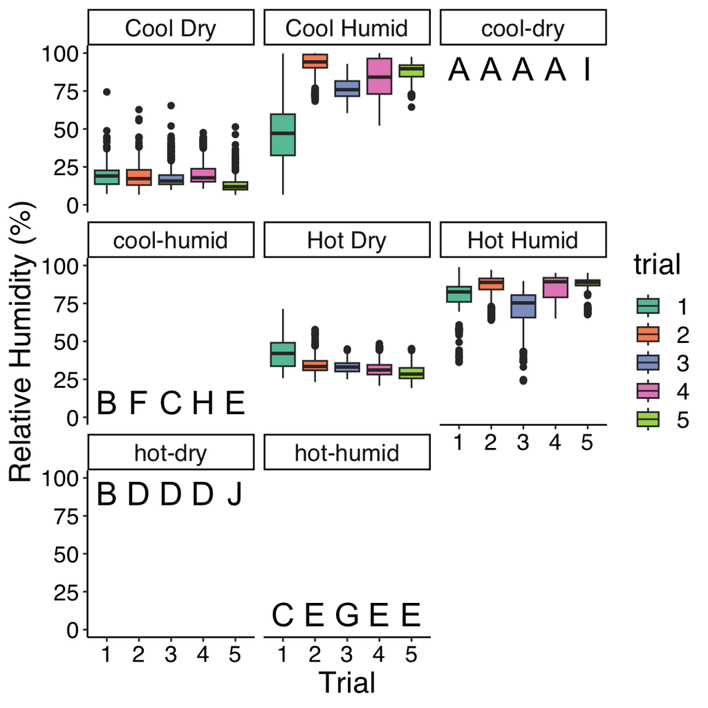

```r
# create ANOVA labels
anova_labels_humidity <- data.frame(tmt = c("cool-dry",
                                   "cool-humid",
                                   "hot-dry",
                                   "hot-humid"
                                  ),
                                # c-d, c-h, h-d, h-h
                                t1 = c("A", "B", "B", "C"),
                                t2 = c("A", "F", "D", "E"),
                                t3 = c("A", "C", "D", "G"),
                                t4 = c("A", "H", "D", "E"),
                                t5 = c("I", "E", "J", "E"))
# plot!
format_HOBO_data %>%
  ggplot() +
  geom_boxplot(aes(x = trial,
                   y = relative_humidity,
                   fill = trial)) +
  theme_classic() +
  facet_wrap(~tmt) +
  xlab("Trial") +
  ylab("Relative Humidity (%)") +
  ylim(0,100) +
  scale_fill_brewer(palette = "Set2") +
  theme(text = element_text(color = "black",
                            family = "sans",
                            size = 18),
        axis.text = element_text(color = "black",
                                 family = "sans",
                                 size = 14),
        legend.text.align = 0,
        legend.position = "right") +
  # trial 1 labels
  geom_text(data = anova_labels_humidity,
            size = 7,
            mapping = aes(x = 1, y = c(90,10,90,10), label = t1)) +
  # trial 2 labels
  geom_text(data = anova_labels_humidity,
            size = 7,
            mapping = aes(x = 2, y = c(90,10,90,10), label = t2)) +
  # trial 3 labels
  geom_text(data = anova_labels_humidity,
            size = 7,
            mapping = aes(x = 3, y = c(90,10,90,10), label = t3)) +
  # trial 4 labels
  geom_text(data = anova_labels_humidity,
            size = 7,
            mapping = aes(x = 4, y = c(90,10,90,10), label = t4)) +
  # trial 5 labels
  geom_text(data = anova_labels_humidity,
            size = 7,
            mapping = aes(x = 5, y = c(90,10,90,10), label = t5)
            ) -> ANOVA_humidity_boxplot
ANOVA_humidity_boxplot
```